# Brazilian Forest Fires, 2016

# Introduction

The Brazilian Government has provided [information](http://dados.gov.br/dataset/sistema-nacional-de-informacoes-florestais-snif) on the fires of the Amazon rainforest. [Luís Gustavo Modelli](https://www.kaggle.com/gustavomodelli) has organized this information into a usable [data set](https://www.kaggle.com/gustavomodelli/forest-fires-in-brazil). Additional [data](https://en.wikipedia.org/wiki/States_of_Brazil) on Brazilian states may be found on Wikipedia.

[interactive chart not shown]

The purpose of this file is to investigate the relationship between the area of a state (measured im km$^2$) and the number of forest firest in that state during 2016.

# Setup

We will use the following libraries.

```r
library(tidyverse)
library(ggrepel)
```

# Load in the Data

We load in the data as follows.

```r
(dat <- read_csv("../brazilFF2016.csv", col_types = cols()))
```

```
## # A tibble: 23 x 6
##    state            fires    area      pop   dens    gdp
##    <chr>            <dbl>   <dbl>    <dbl>  <dbl>  <dbl>
##  1 Acre              6993  164124   881935   5.37  13751
##  2 Alagoas            400   27843  3337357 120.    49456
##  3 Amapá             2653  142471   845731   5.94  14339
##  4 Amazonas         12023 1559168  4144597   2.66  89017
##  5 Bahia             6751  564723 14873064  26.3  258649
##  6 Ceará             3245  148895  9132078  61.3  138379
##  7 Distrito Federal   242    5761  3015268 523.   235497
##  8 Espírito Santo     654   46074  4018650  87.2  109227
##  9 Goiás             5275  340126  7018354  20.6  181692
## 10 Maranhão         21766  329642  7075181  21.5   85286
## # ... with 13 more rows
```

# Visualizations

We visualize state area and number of fires.

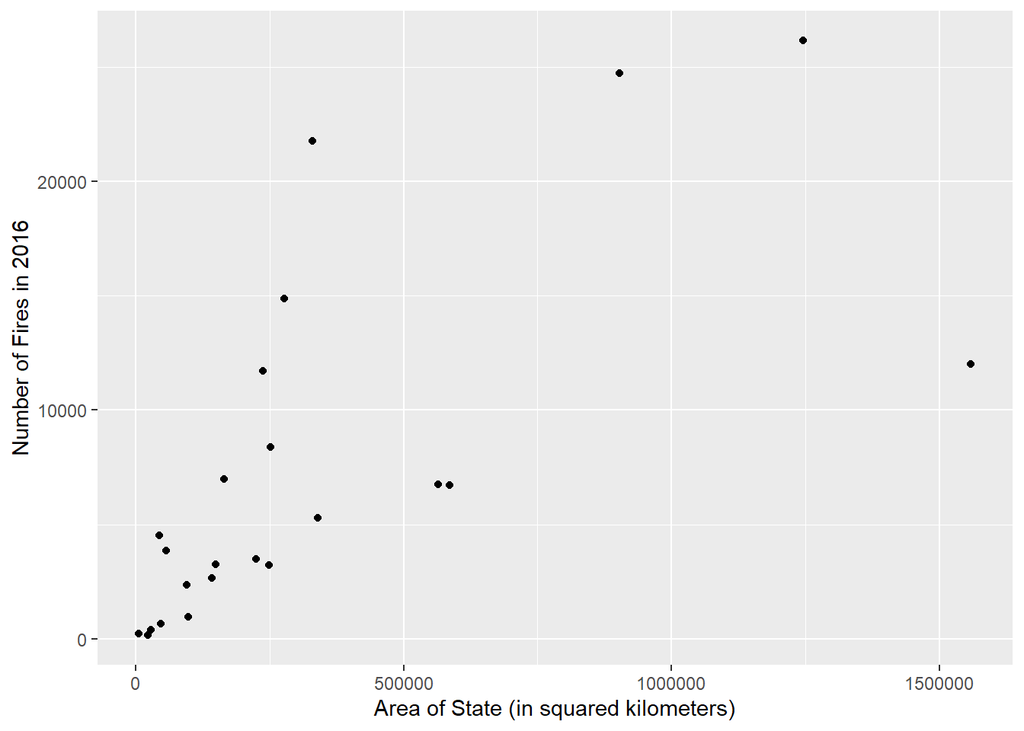

```r
ggplot(data = dat, mapping = aes(x = area, y = fires)) +
  geom_point() +
  labs(x = "Area of State (in squared kilometers)",
         y = "Number of Fires in 2016")
```

Let’s add some labels so that we can identify the some of the states we are looking at. We won’t add labels to the cluster of points near the origin of the graph (i.e., the states with less than 5000 fires).

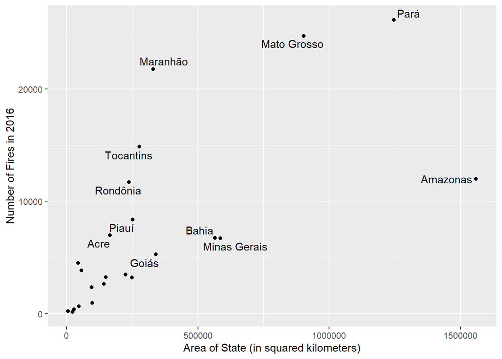

```r
# Create Partially Labeled Data
pldat <-
  dat %>%
  mutate(has_space = (fires > 5000)) %>%
  mutate(label = case_when(has_space ~ state))
# Plot
ggplot(data = pldat, mapping = aes(x = area, y = fires, label = label )) +
  geom_point() +
  geom_text_repel() +
  labs(x = "Area of State (in squared kilometers)",
       y = "Number of Fires in 2016")
```

# Transformation

The distribution of state areas is skewed to the right. Let’s do a natural log transformation and visualize the results.

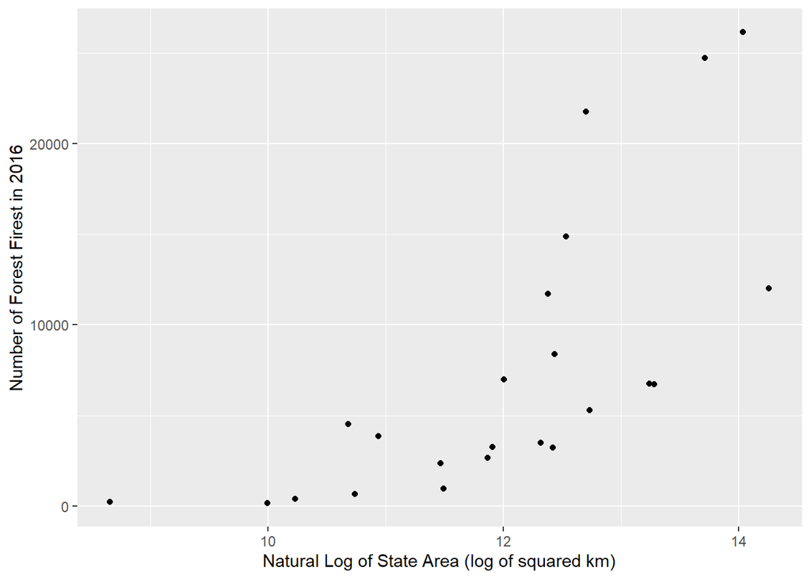

```r
# Transformed Data
tdat <-
  dat %>%
  mutate(logarea = log(area))
# Plot
p <- ggplot(data = tdat, mapping = aes(x = logarea, y = fires)) +
  geom_point() +
  labs(x = "Natural Log of State Area (log of squared km)",
       y = "Number of Forest Firest in 2016")

p
```

# Model

Let $Y_i$ denote the number of forest fires for $\texttt{state}_i$ in 2016 and let $\texttt{area}_i$ denote the area of $\texttt{state}_i$ in squared kilometers.

Consider the generalized linear model (GLM) whose

- random component is $Y_i \sim \text{Poisson}(\lambda_i)$,
- Linear Predictor is $\beta_0 + \beta_1 \log \texttt{area}_i$, and
- Link Function is $g(\lambda_i) = \log \lambda_i$.

```r
glm(fires ~ log(area), data = dat, family = poisson(link = "log"))
```

```
##
## Call:  glm(formula = fires ~ log(area), family = poisson(link = "log"),
##     data = dat)
##
## Coefficients:
## (Intercept)    log(area)
##      0.4961       0.6727
##
## Degrees of Freedom: 22 Total (i.e. Null);  21 Residual
## Null Deviance:       160600
## Residual Deviance: 60320     AIC: 60550
```

The model
$$\log \lambda_i = \beta_0 + \beta_1 \log \texttt{area}_i$$

gives rise to the following estimates:
$$\hat{\beta}_0 \approx 0.4961
\quad
\hat{\beta}_1 \approx 0.6727$$
We see that $\lambda_i$, which is the expected value of $Y_i$, may be written as
$$\lambda_i \approx \exp (0.4961 + 0.6727 \log \texttt{area}_i)$$

We can visualize this “fit” as follows.

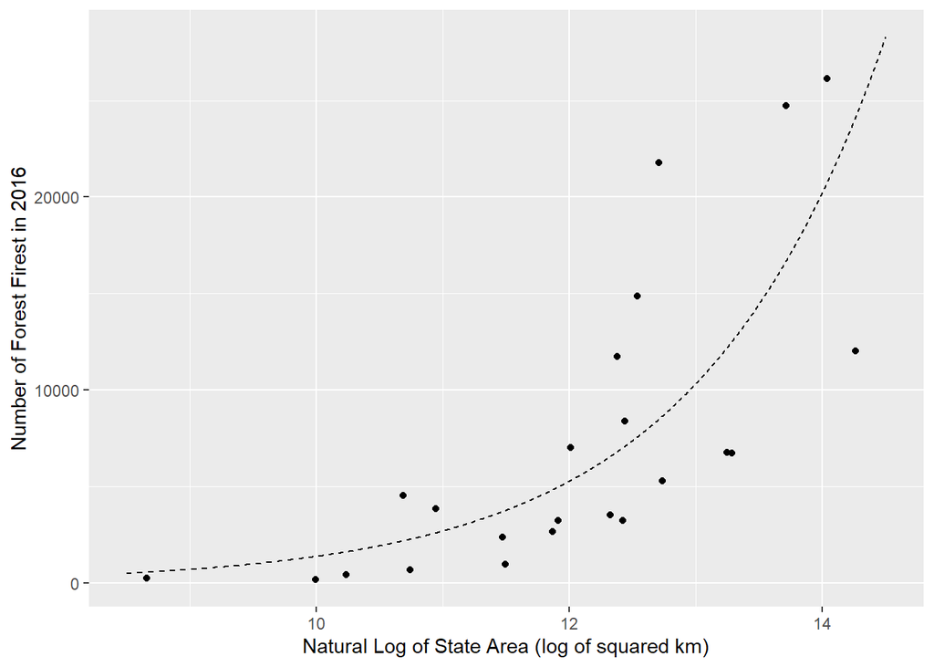

```r
# Use expected values as predictions over an approprate Domain
domain <- seq(from = exp(8.5), to = exp(14.5), length.out = 10^4) %>% log()
# Use estimates to obtain predictions
range <- exp(0.496134 + 0.672717*domain)
# Gather prediction data for plot
to_plot <- tibble(x = domain, y = range)

# Add
(p2 <- p + geom_path(data = to_plot, mapping = aes(x = x, y =y), linetype = 'dashed'))
```

# Final Visualization

Let’s add some labels to this plot and change the plot theme.

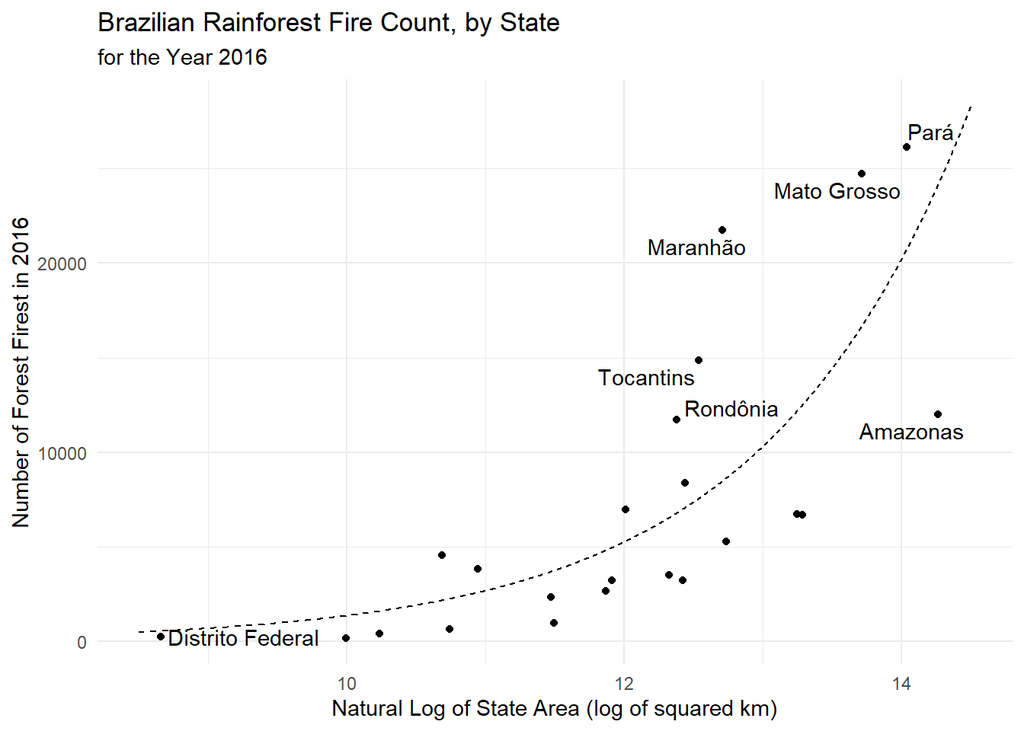

```r
pldat <-
  dat %>%
  mutate(has_space = (fires > 10000 | log(area) < 9)) %>%
  mutate(label = case_when(has_space ~ state))
# Plot
(p3 <- p2 +
    geom_text_repel(data = pldat, mapping = aes(x = log(area), y = fires, label = label)) +
    labs(title = "Brazilian Rainforest Fire Count, by State",
       subtitle = "for the Year 2016") +
  theme_minimal())
```

# Conclusion

As expected, we saw that the numer of forest fires tended to increase with state size. In the future, we may wish to investigate additional sources of variation with respect to the number of forest fires.